# Prob Wkshp 1

```r
library(tidyverse)
```

Setting up the deck…

```r
deck <- tibble(
  # tibble is a more flexible data.frame
  card = rep(
    c("ace",
      "deuce",
      "three",
      "four",
      "five",
      "six",
      "seven",
      "eight",
      "nine",
      "ten",
      "jack",
      "queen",
      "king"
    ),4),
  suit =
    rep(c(
      "diamonds",
      "hearts",
      "clubs",
      "spades"),
        each = 13),
  color = rep(c("red",
                "black"),
              each = 26)
)

glimpse(deck)
```

```
## Rows: 52
## Columns: 3
## $ card  <chr> "ace", "deuce", "three", "four", "five", "six", "seven", "eight"…
## $ suit  <chr> "diamonds", "diamonds", "diamonds", "diamonds", "diamonds", "dia…
## $ color <chr> "red", "red", "red", "red", "red", "red", "red", "red", "red", "…
```

And running some warm-up probabilities…

```r
pr_black <- deck %>%
  filter(color == "black") %>%
  nrow()/nrow(deck)

pr_ace <- deck %>%
  filter(card == "ace") %>%
  nrow()/nrow(deck)

pr_black_and_ace <- deck %>%
  filter(card == "ace" & color == "black") %>%
  nrow()/nrow(deck)

pr_black + pr_ace - pr_black_and_ace
```

```
## [1] 0.5384615
```

## Question 1

**Your friend wants to know the probability of getting one black card first and then one red card in two draws with replacement. Use your data wrangling tools to answer this question.**

I’ll answer this by first writing code to find the probability of both events…

```r
pr_oneblack <- deck |>
  filter(color == "black") |>
  nrow()/nrow(deck)

pr_onered <- deck |>
  filter(color == "red") |>
  nrow()/nrow(deck)
```

Then, since these are independent events, I can find the probability of drawing one black AND one red by multiplying those two together…

```r
pr_oneblack * pr_onered
```

```
## [1] 0.25
```

**Okay, impressed with your skills, your friend asks a more specific question: what’s the probability of getting one king or one ace in a single draw.**

Using a filter statement, I can answer this (I’ll also use simple math to check my work)…

```r
deck |>
  filter(card == "king" | card == "ace") |>
  nrow()/nrow(deck)
```

```
## [1] 0.1538462
```

```r
(4+4)/52
```

```
## [1] 0.1538462
```

**Alright, what’s the probability of getting two aces in two draws with replacement?**

Again, filter statements followed by multiplication will give me the answer, since the events are independent (and I’ll check my work using just the math)…

```r
pr_oneace <- deck |>
  filter(card == "ace") |>
  nrow()/nrow(deck)

pr_oneace * pr_oneace
```

```
## [1] 0.00591716
```

```r
(4/52) * (4/52)
```

```
## [1] 0.00591716
```

## Question 2

**Your friend asks you to give them an example of what some hands might look like. A hand in Poker consists of 5 cards sampled without replacement. Give your friend an example of five randomly sampled hands.**

```r
sample_n(deck, size=5, replace = FALSE)
```

```
## # A tibble: 5 × 3
##   card  suit     color
##   <chr> <chr>    <chr>
## 1 six   diamonds red
## 2 ten   spades   black
## 3 three diamonds red
## 4 eight spades   black
## 5 six   clubs    black
```

```r
sample_n(deck, size=5, replace = FALSE)
```

```
## # A tibble: 5 × 3
##   card  suit     color
##   <chr> <chr>    <chr>
## 1 six   clubs    black
## 2 four  spades   black
## 3 queen spades   black
## 4 queen diamonds red
## 5 nine  hearts   red
```

```r
sample_n(deck, size=5, replace = FALSE)
```

```
## # A tibble: 5 × 3
##   card  suit     color
##   <chr> <chr>    <chr>
## 1 six   hearts   red
## 2 king  clubs    black
## 3 six   diamonds red
## 4 four  spades   black
## 5 ace   hearts   red
```

```r
sample_n(deck, size=5, replace = FALSE)
```

```
## # A tibble: 5 × 3
##   card  suit   color
##   <chr> <chr>  <chr>
## 1 deuce spades black
## 2 queen spades black
## 3 four  clubs  black
## 4 six   clubs  black
## 5 nine  spades black
```

```r
sample_n(deck, size=5, replace = FALSE)
```

```
## # A tibble: 5 × 3
##   card  suit     color
##   <chr> <chr>    <chr>
## 1 king  diamonds red
## 2 queen diamonds red
## 3 ten   diamonds red
## 4 four  clubs    black
## 5 jack  clubs    black
```

**Excitedly, they ask what is the total number of different hands you could draw in Poker.**

```r
choose(52,5)
```

```
## [1] 2598960
```

## Question 3

**Aware of your skills, your friend is going to try to push you a bit. They ask about the probability that each suit is represented in a hand.** Any of the suits could be the one with 2 cards pulled, so there are 4 different possibilities for choosing which suit has 2 cards. Then, there are 13c2 possibilities of what cards are in the hand from that suit. For the other three suits, there are 13 possibilities for what card is in the hand. Once we multiply all of this together, we divide by the total number of possible poker hands to get the probability…

```r
((4*(13*12/2)*13*13*13))/2598960
```

```
## [1] 0.2637455
```

## Question 4

**Last question, they promise. What’s the probability of getting at least one Ace in one 5-card hand?**

The probability of AT LEAST ONE is the same as 1 minus the probability of NONE.The probability of drawing anything but an ace on the first draw is 48 (the number of cards that aren’t an ace) divided by 52 (the cards in the deck). For the second draw, there is one less card that isn’t an ace, and also one less card in the deck, so the probability is 47 / 51, and so on up until five cards. So…

```r
1 - (48/52)*(47/51)*(46/50)*(45/49)*(44/48)
```

```
## [1] 0.341158
```

## Question 5

```r
df <- tibble(
          id   = 1:6,
          name = c('Alice', 'Bob', 'Charlie', 'Diane', 'Fred', 'Jenny')
            )

df_pairs <- df %>%
  rename(id1 = id, name1 = name) %>%
  crossing(df %>%
             select(id2 = id, name2 = name)) %>%
  filter(id1 < id2) %>%
  unite(id, id1, id2) %>%
  unite(name, name1, name2)
```

An “analytic” solution to this would be to use the arithmetic formula for how many COMBINATIONS of 2 can be pulled from a group of 6…

```r
6*5/2
```

```
## [1] 15
```

## Question 6

```r
df <- tibble(
          id   = 1:6,
          name = c('Alice', 'Bob', 'Charlie', 'Diane', 'Fred', 'Jenny')
            )

df_pairs2 <- df %>%
  rename(id1 = id, name1 = name) %>%
  crossing(df %>%
             select(id2 = id, name2 = name)) %>%
  filter(id1 != id2) %>%
  unite(id, id1, id2) %>%
  unite(name, name1, name2)
```

The analytical solution to this would be to use the formula for how many PERMUTATIONS of 2 can be drawn from a group of 6…

```r
6*5
```

```
## [1] 30
```

## Question 7

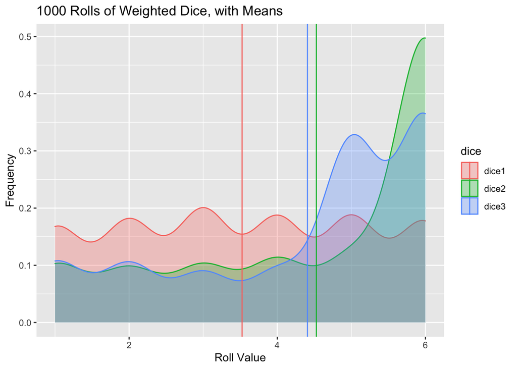

```r
dice1 <- replicate(1000, sample(6,1, replace=TRUE))

dice2 <- replicate(1000, sample(6,1, replace=TRUE, prob=c(.1,.1,.1,.1,.1,.5)))

dice3 <- replicate(1000, sample(6,1, replace=TRUE, prob=c((1/12),(1/12),(1/12),(1/12),(1/3),(1/3))))

dicedata <- data.frame(dice1,dice2,dice3)

dicedatalong <- dicedata |> gather(key="dice", value="rollvalue")

meanroll <- dicedatalong |>
  group_by(dice) |>
  summarize(mean=mean(rollvalue))

ggplot(data=dicedatalong, aes(x=rollvalue, color=dice, fill=dice))+
  geom_density(alpha=.3) +
  geom_vline(data=meanroll, aes(xintercept=mean,color=dice)) +
  labs(x="Roll Value", y="Frequency", title="1000 Rolls of Weighted Dice, with Means")
```